# One-step vehicle count forecasts on US-101

This case uses the total vehicle count from five-minute mainline station records in District 4. Upstream and downstream ordering follows absolute postmile on northbound US-101. The source’s detector-observation percentage indicates where provider estimates can enter the reported totals.

**Run scope.** The **smoke** run contains 4 directed series and 288 time bins, with 48 final bins reserved for sequential forecasting. These scores check the workflow on the sample and are unsuitable for ranking methods in the manuscript.

## Forecast comparison

Each method is scored on the same held-out counts. The log score integrates predictive uncertainty for models supplying a distribution. Larger log scores and smaller count errors indicate better forecasts. Interpret interval coverage with its width.

| Method | Cells | Deviance | MAE | RMSE | Log_score | Coverage | Width |
| --- | --- | --- | --- | --- | --- | --- | --- |
| GLS continuous | 192 | 4.177 | 24.563 | 30.636 | -5.489 | 0.682 | 64.781 |
| GLS joint DSS | 192 | 4.241 | 24.552 | 30.801 | -5.506 | 0.703 | 67.422 |
| graph-wavenet | 192 | 7.635 | 33.208 | 40.931 | NA | NA | NA |
| pnar1 | 192 | 4.117 | 24.138 | 30.003 | -5.700 | 0.661 | 59.182 |
| pnar2 | 192 | 3.030 | 20.559 | 25.798 | -5.157 | 0.745 | 59.880 |
| sa-pgss | 192 | 4.745 | 26.355 | 32.532 | -5.547 | 0.698 | 69.552 |

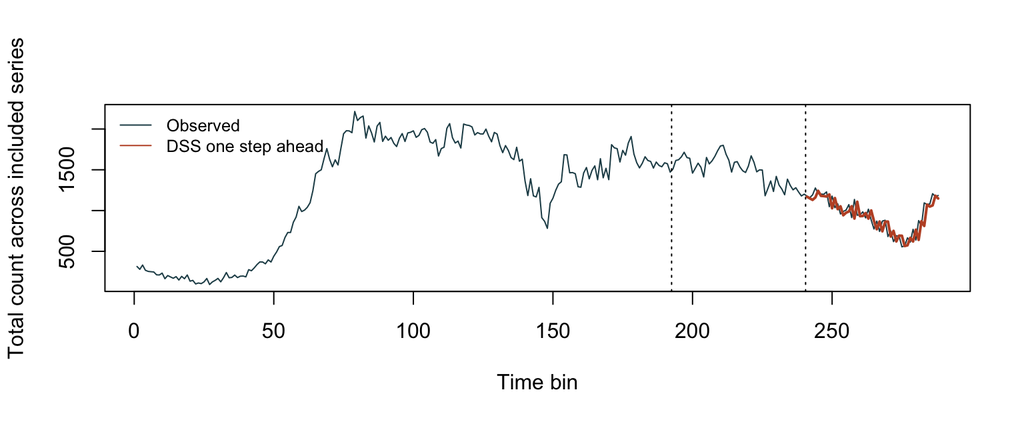

## From the raw observations to a time series

| Field | Detail |
| --- | --- |
| source | California Department of Transportation, PeMS District 4 station five-minute totals and metadata |
| date | 06/16/2026 |
| timezone | America/Los_Angeles |
| scope | One observed day on one Bay Area corridor. |
| selection | Four consecutive distinct-postmile mainline stations on D04 US-101 northbound maximizing mean training percent observed, each with all training counts present. Ties choose the furthest upstream. |
| graph | Station series are ordered by ascending absolute postmile on US-101 northbound. Each downstream station has its immediate upstream station as physical predecessor. |
| observation_scope | Provider-reported totals can include PeMS estimates when V9 is below 100 percent. V9 is retained by bin and station. |

| Block | Bins | Counts | Zero_fraction |
| --- | --- | --- | --- |
| train | 192 | 240252 | 0 |
| validation | 48 | 71550 | 0 |
| test | 48 | 45631 | 0 |

## Model and diagnostics

The continuous GLS fit and its sparse DSS projection share the training posterior. Validation selects the projection. Each test forecast uses observations available before the scored bin. The selected graph retains **16** of **16** candidate relationships. The diagnostic counts show how many monitored summaries have finite estimates and how many miss the declared thresholds.

| Statistics | Available_Rhat | Rhat_above_target | Available_ESS | ESS_below_target |
| --- | --- | --- | --- | --- |
| 63 | 63 | 62 | 63 | 63 |

## Reproduce from the repository root

Install the optional Python dependencies for Graph WaveNet as described in the GLS paper README. Set `RESULTS` to an external directory on the data or SSD volume. Preparation writes the count panel, source checksums and an exploratory plot. The application runner fits the training window, selects on validation, scores the held-out window and saves compact outputs. Report mode exports individual forecast cells and diagnostics. The final command rebuilds the executive report without fitting.

```bash
Rscript GLS-paper/applications/pems/prepare.R --output="$RESULTS/pems-prepared.rds"
Rscript GLS-paper/applications/run.R --action=run --profile=smoke --benchmarks=pnar1,pnar2,sa-pgss,graph-wavenet --input="$RESULTS/pems-prepared.rds" --output="$RESULTS/pems"
Rscript GLS-paper/applications/run.R --action=report --output="$RESULTS/pems"
Rscript GLS-paper/reports/render.R pems "$RESULTS/pems"
```